# Điều chỉnh chú thích (legend)

```python
import matplotlib.pyplot as plt
from matplotlib.ticker import FuncFormatter
import numpy as np
```

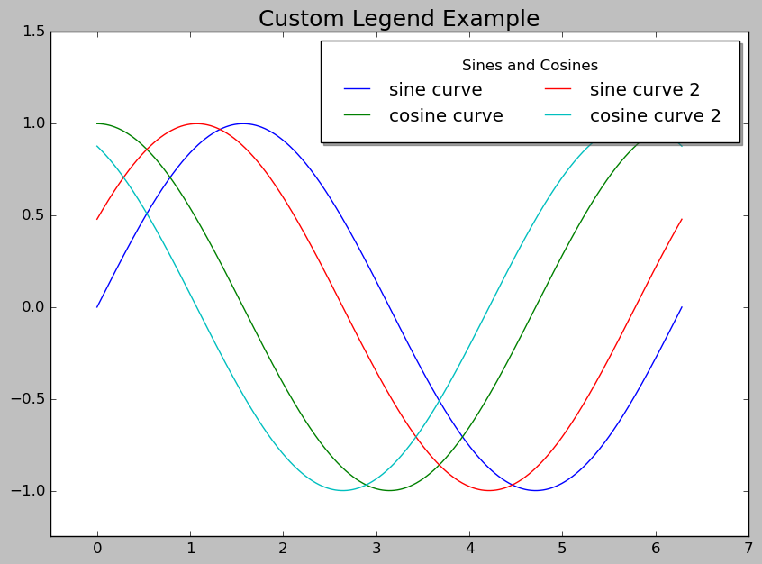

```python
X = np.linspace(0, 2*np.pi, 1000)
# Tạo biểu đồ đơn giản
plt.style.use('classic')
plt.figure(figsize = (10, 7), dpi = 100)

sine = plt.plot(X, np.sin(X)); cosine = plt.plot(X, np.cos(X))
sine_2 = plt.plot(X, np. sin(X + .5)); cosine_2 = plt.plot(X, np.cos(X + .5))

plt.gca().set(ylim = (-1.25, 1.5), xlim = (-.5, 7))
plt.title('Custom Legend Example', fontsize = 18)

# custom legend
plt.legend([sine[0], cosine[0], sine_2[0], cosine_2[0]], # plot items
          ['sine curve', 'cosine curve', 'sine curve 2', 'cosine curve 2'],
          framealpha = 1,                           # transparency of border
          ncol=2,                                      # num columns
          shadow = True,                                 # shadow on
          borderpad = 1,                                 # thickness of border
          title = 'Sines and Cosines',                   # title
          )
plt.show()
```

Nếu truyền vào **title**, mặc định **legend** sẽ tìm các đối tượng được vẽ và chú thích **label** của chúng. Nếu không muốn chú thích toàn bộ hãy chỉ đưa vào những đối tượng mà bạn muốn chú thích, như trong ví dụ trên là **sine, cosine, sine_2 và cosine_2 và list** các **label** tương ứng của chúng là ['sine curve', 'cosine curve', 'sine curve 2', 'cosine curve 2'].

Ngoài ra các tham số khác như:

- **framealpha** : Độ trong suốt của khung chú thích, có thể kiểm tra giá trị này bằng mpl.rcParams["legend.framealpha"]
- **loc** : Vị trí của khung chú thích trong biểu đồ, các giá trị như 'best', 'center', 'left center', 'right center', 'lower center', 'lower left', ...
- **ncol** : số cột (trong ví dụ chú thích thành 2 cột)
- **shadow** : True hay False. Viền có đổ bóng hay không
- **title** : Title của khung chú thích
- **borderpad** : Khoảng cách từ chú thích đến viền